# Exploratory Data Analysis - 'DIE ZEIT' Churn Prediction

## **Table of Content**

1. Introduction
2. Environments
3. Business Understanding
   - 3.1 Data Set
   - 3.2 Check for duplicates
   - 3.2 Missing values
   - 3.3 Outliers & Anomalies
4. Exploring the data in more depth
   - 4.1 Target variable: churn
   - 4.2 Demografics
   - 4.3 ZON-Columns
   - 4.4 CNT-Columns
   - 4.5 NL-Columns
   - 4.6 Reg-Columns
   - 4.7 Newsletter-Columns
     - Total e-mails recieved by all customers
     - E-mails recieved by established customers
     - Product newsletter
     - Hamburg newsletter
     - ZEITBRIEF newsletter
5. Feature Engineering

## **1 - Introduction**

#### **Project Name**

Neuefische Capstone Project: 'DIE ZEIT' Churn Prediction

#### **Description**

The task of this data science project is it to perform a churn prediction based on the cancellations of previous years. So, basically answering the question 'Which customer is canceling his or her subscription within the next year?'. To answer this question a model should get trained with the data from previous years (after 2012) to predict the affinity of canceling per order.

This notebook contains the exploratory data analysis to gather initial information about the processed data set and preprocess the data for the next step of modeling.

The the target variable is `churn`.

#### **Team**

- Kevin Tomas
- Sebastian Rötten
- Chandrakantha Hassan Anantharajaiah
- Michael Leder

#### **Time Period**

**Project Start:** 23/11/2020  
**Project End:** 18/12/2020

## **Findings**

### **Count Features:**

- people with more than one subscription tend to churn less (28%) than people with a single subscription (34%)
- people who tested their subscription before paying for it are less likely to churn (25% vs. 35%)

### **ZON - Features:**

- for every feature (except zon_sonstige), **the churn rates for non-registered users are lower than for the users, who completed the registration.**

### **E-Mailings:**

- E-Mailing & Newsletters have generally a negative effect on churning subscribers
- the only E-Mailing that has fewer subscribers churning than the average is "Produkt News"

### **Our desired subscriber without loosing bigger target groups:**

Is a Zeit Digital customer who pays via direct debit. A low payment frequency of a yearly or even 2 yearly turnus should be advertised by special discounts an offerings like a special "productnews" mailing. He probably has a academic degree but is not a student anymore.

## **2 - Environments, Imports and Settings**

```python
import numpy as np
import pandas as pd

import seaborn as sns
import matplotlib.pyplot as plt

import functions_eda as eda
#from eda_functions import geo_pandas_function as geo

from matplotlib.patches import Shadow
from matplotlib.font_manager import FontProperties
from datetime import datetime

%matplotlib inline
#sns.set_theme(style="whitegrid")
sns.set_palette('Set2')
```

```python
# Define decimal places shown in the notebook
pd.options.display.float_format = '{:,.3f}'.format

# Display the whole content of the data frame
pd.set_option('display.max_columns', None)   # Displays all columns
pd.set_option('display.max_rows', None)      # Displays all rows

# Ignore warnings while plotting
import warnings
warnings.filterwarnings("ignore")
```

## **3 - Business Understanding**

### **3.1 - Data Set**

We load a working set and a original set to keep track of changes in size during cleaning:

```python
df = pd.read_csv("00_data/f_chtr_churn_traintable_nf.csv")
```

```python
df_origin = pd.read_csv("00_data/f_chtr_churn_traintable_nf.csv")
```

```python
df.shape
```

```
(209043, 171)
```

```python
df.head(2)
```

|  | Unnamed: 0 | auftrag_new_id | liefer_beginn_evt | kanal | objekt_name | aboform_name | zahlung_rhythmus_name | lesedauer | rechnungsmonat | zahlung_weg_name | studentenabo | plz_1 | plz_2 | plz_3 | ort | metropole | land_iso_code | shop_kauf | unterbrechung | anrede | titel | avg_churn | email_am_kunden | zon_che_opt_in | zon_sit_opt_in | zon_zp_grey | zon_premium | zon_boa | zon_kommentar | … |
| --- | --- | --- | --- | --- | --- | --- | --- | --- | --- | --- | --- | --- | --- | --- | --- | --- | --- | --- | --- | --- | --- | --- | --- | --- | --- | --- | --- | --- | --- | --- |
| 0 | 0 | 6BE5B590-07EA-4543-B422-F7ABB2AF9464 | 2013-10-02 | andere | ZEIT Digital | Probeabo | jährlich | 68 | 0 | Bankeinzug | 0 | 6 | 64 | 647 | Erbach | 0 | DE | 4 | 0 | Frau | akademischer Titel | 0.134 | 1.000 | 0 | 0 | 0 | 0 | 0 | 0 | … |
| 1 | 1 | 2271CE79-EAC2-42EE-9702-BF5CCCF4E1BE | 2013-10-02 | andere | ZEIT Digital | Probeabo | jährlich | 68 | 0 | Bankeinzug | 0 | 6 | 64 | 647 | Erbach | 0 | DE | 4 | 0 | Frau | akademischer Titel | 0.134 | 1.000 | 0 | 0 | 0 | 0 | 0 | 0 | … |

`auftrag_new_id` --> Apparently, for one subscription several `auftrag_new_id` can be created.  
`zon-columns` --> These zon-columns (ZeitOnline) are independant from the subscrition itself (you can be a subscripter and not be registered for ZeitOnline services)  
`cnt-columns` --> This is the total amount of abos per user. You could for example get a new subscritpion for "Zeit Digital" but already be subscriptor of "Die Zeit" and "Zeit Magazin". If `cnt_abo == 0` it means, that except for the new subscription, no further subscriptions exist.  
`nl-columns` --> Count of registrations for the newsletters. In this dataset, not all newsletters are included. This explains the difference between the sum of `nl_zeitbrief,nl_zeitshop and nl_zeitverlag_hamburg` and `nl_aktivitaet`  
`reg-columns` --> Count of registrations for these services. Independant from the features before

For the sake of consistency, we will rename some columns

```python
df.rename({'openedanzahl_6m':'opened_anzahl_6m',
           'openedanzahl_bestandskunden_6m':'opened_anzahl_bestandskunden_6m',
           'openedanzahl_hamburg_6m': 'opened_anzahl_hamburg_6m',
           'openedanzahl_produktnews_6m': 'opened_anzahl_produktnews_6m',
           'openedanzahl_zeitbrief_6m': 'opened_anzahl_zeitbrief_6m',
          }, axis=1, inplace=True)
```

### 3.2 - Check for duplicates

For checking the duplicates, we will drop `Unnamed: 0` and `auftrag_new_id`, because we know that these are unique. Still, we need to check, if there are duplicates based on the rest of the columns.

```python
df_temp = df
df_temp = df_temp.drop(["Unnamed: 0","auftrag_new_id"], axis=1)
```

```python
df_temp_duplicates = df_temp[df_temp.duplicated()]
df_temp_duplicates.shape
```

```
(48319, 169)
```

Apparently, we have around **50k duplicates**. We will drop them and the columns `Unnamed: 0` and `auftrag_new_id`

```python
df = df.drop(["Unnamed: 0","auftrag_new_id"], axis=1).drop_duplicates()
```

```python
df_dup = df
df_dup.shape[0]
```

```
160724
```

### 3.3 - Missing values

```python
df.isnull().sum().sort_values()[::-1][:5]
```

```
kuendigungs_eingangs_datum    110802
ort                               85
email_am_kunden                   12
sit_reg                            0
opened_anzahl_3m                   0
dtype: int64
```

There are many missing values for `kuendigungs_eingangs_datum`. Since `kuendigungs_eingangs_datum` has only entries in it, if the subscritpor has churned, it is quit logical having these missing values. Therefore we will not drop them, but replace the NaN's with the date of the data query.  
The missing values for `ort`and `email_am_kunden` will be dropped though.

```python
df.kuendigungs_eingangs_datum.fillna(value='2020-05-26', inplace=True)
```

```python
df = df.dropna(subset=['ort', 'email_am_kunden'])
df_na = df
```

```python
df.shape
```

```
(160639, 169)
```

### 3.4 - Outliers & Anomalies

Before we move on with the analysis, we firstly have to check for outliers and decide, how to handel them.

Many variables have outliers which are outside of multiple standard deviations from the mean:

**Check max values for:**

- shop_kauf (152)
- cnt_abo(7,104)
- cnt_abo_diezeit(3,708)
- cnt_abo_diezeit_digital (516)
- cnt_abo_magazin(414)
- cnt_umwandlungsstatus2_dkey(3,129)
- nl_blacklist_sum (22)
- nl_bounced_sum (16)
- nl_aktivitaet (39)
- nl_sperrliste_sum (133)
- nl_opt_in_sum (19)
- the counts of all 5 newsletter types regarding received & opened emails
- all "rates" with values > 1 (not feasible)

```python
df.describe().T.head(25)
```

|  | count | mean | std | min | 25% | 50% | 75% | max |
| --- | --- | --- | --- | --- | --- | --- | --- | --- |
| lesedauer | 160,639.000 | 31.565 | 21.438 | 0.000 | 13.000 | 26.000 | 46.000 | 88.000 |
| rechnungsmonat | 160,639.000 | 0.099 | 0.299 | 0.000 | 0.000 | 0.000 | 0.000 | 1.000 |
| studentenabo | 160,639.000 | 0.105 | 0.307 | 0.000 | 0.000 | 0.000 | 0.000 | 1.000 |
| metropole | 160,639.000 | 0.290 | 0.454 | 0.000 | 0.000 | 0.000 | 1.000 | 1.000 |
| shop_kauf | 160,639.000 | 0.463 | 2.279 | 0.000 | 0.000 | 0.000 | 0.000 | 152.000 |
| unterbrechung | 160,639.000 | 0.098 | 0.298 | 0.000 | 0.000 | 0.000 | 0.000 | 1.000 |
| avg_churn | 160,639.000 | 0.316 | 0.149 | 0.101 | 0.190 | 0.292 | 0.407 | 0.702 |
| email_am_kunden | 160,639.000 | 0.919 | 0.273 | 0.000 | 1.000 | 1.000 | 1.000 | 1.000 |
| zon_che_opt_in | 160,639.000 | 0.002 | 0.050 | 0.000 | 0.000 | 0.000 | 0.000 | 2.000 |
| zon_sit_opt_in | 160,639.000 | 0.001 | 0.034 | 0.000 | 0.000 | 0.000 | 0.000 | 2.000 |
| zon_zp_grey | 160,639.000 | 0.162 | 0.457 | 0.000 | 0.000 | 0.000 | 0.000 | 2.000 |
| zon_premium | 160,639.000 | 0.163 | 0.459 | 0.000 | 0.000 | 0.000 | 0.000 | 2.000 |
| zon_boa | 160,639.000 | 0.008 | 0.101 | 0.000 | 0.000 | 0.000 | 0.000 | 2.000 |
| zon_kommentar | 160,639.000 | 0.003 | 0.069 | 0.000 | 0.000 | 0.000 | 0.000 | 2.000 |
| zon_sonstige | 160,639.000 | 0.045 | 0.257 | 0.000 | 0.000 | 0.000 | 0.000 | 2.000 |
| zon_zp_red | 160,639.000 | 0.042 | 0.246 | 0.000 | 0.000 | 0.000 | 0.000 | 2.000 |
| zon_rawr | 160,639.000 | 0.000 | 0.019 | 0.000 | 0.000 | 0.000 | 0.000 | 2.000 |
| zon_community | 160,639.000 | 0.000 | 0.006 | 0.000 | 0.000 | 0.000 | 0.000 | 2.000 |
| zon_app_sonstige | 160,639.000 | 0.003 | 0.063 | 0.000 | 0.000 | 0.000 | 0.000 | 2.000 |
| zon_schach | 160,639.000 | 0.000 | 0.020 | 0.000 | 0.000 | 0.000 | 0.000 | 2.000 |
| zon_blog_kommentare | 160,639.000 | 0.000 | 0.026 | 0.000 | 0.000 | 0.000 | 0.000 | 2.000 |
| zon_quiz | 160,639.000 | 0.000 | 0.021 | 0.000 | 0.000 | 0.000 | 0.000 | 2.000 |
| cnt_abo | 160,639.000 | 7.248 | 170.450 | 0.000 | 0.000 | 1.000 | 2.000 | 7,104.000 |
| cnt_abo_diezeit | 160,639.000 | 4.713 | 98.764 | 0.000 | 0.000 | 0.000 | 1.000 | 3,708.000 |
| cnt_abo_diezeit_digital | 160,639.000 | 0.504 | 11.351 | 0.000 | 0.000 | 0.000 | 0.000 | 516.000 |

**Shop-Kauf**

- 87.7% have **never ordered** in the zeit-shop
- 99% of the customers order **less than 10 Products** from the zeit shop
- only 3 customers order 152 products, the runners up order 80 Units from the zeitshop, from 80 orders down the dirstribution is continouus, so we delete the 3 Outliers.

```python
df.iloc[:, 0:20].query('shop_kauf > 1').sort_values('shop_kauf', ascending=False).head(5)
```

|  | liefer_beginn_evt | kanal | objekt_name | aboform_name | zahlung_rhythmus_name | lesedauer | rechnungsmonat | zahlung_weg_name | studentenabo | plz_1 | plz_2 | plz_3 | ort | metropole | land_iso_code | shop_kauf | unterbrechung | anrede | titel | avg_churn |
| --- | --- | --- | --- | --- | --- | --- | --- | --- | --- | --- | --- | --- | --- | --- | --- | --- | --- | --- | --- | --- |
| 103446 | 2018-08-09 | Eigenwerbung | DIE ZEIT | Geschenkabo | jährlich | 15 | 0 | Rechnung | 0 | 5 | 50 | 506 | Köln | 1 | DE | 152 | 1 | Frau | kein Titel | 0.282 |
| 61880 | 2015-04-01 | Telefonmarketing | ZEIT Digital | Festabo | jährlich | 57 | 0 | Bankeinzug | 0 | 9 | 97 | 977 | Hammelburg | 0 | DE | 152 | 0 | Herr | akademischer Titel | 0.184 |
| 27630 | 2013-12-27 | Telefonmarketing | DIE ZEIT | Festabo | jährlich | 73 | 0 | Rechnung | 0 | 9 | 97 | 977 | Hammelburg | 0 | DE | 152 | 1 | Herr | akademischer Titel | 0.168 |
| 80065 | 2017-06-08 | E-Mailing | DIE ZEIT | Negative Option | halbjährlich | 26 | 0 | Bankeinzug | 0 | 5 | 53 | 538 | Niederkassel | 0 | DE | 80 | 0 | Herr | kein Titel | 0.387 |
| 7619 | 2013-05-16 | E-Mailing | DIE ZEIT | Probeabo | halbjährlich | 77 | 0 | Bankeinzug | 0 | 1 | 14 | 140 | Berlin | 1 | DE | 78 | 1 | Frau | kein Titel | 0.310 |

```python
df.shop_kauf.value_counts(1).head(5)
```

```
0   0.877
1   0.043
2   0.030
3   0.012
4   0.011
Name: shop_kauf, dtype: float64
```

```python
df = df[df.shop_kauf < 100]
```

**cnt_abo**

- How many subscriptions per ID make sense?
- In the year **1967** we have some inconsistency regarding `cnt_abo` with values >7000
- until 20 subscriptions the data seems to be continous
- a high count of subscriptions seem to be a historic relict in the later years the companies model seems to be unified
- we delete values > 20 which reduces the dataframe by 775 rows

```python
df["abo_registrierung_min_YEAR"] = df["abo_registrierung_min"].apply(lambda x: x.split()[0].split("-")[0])
df = df.sort_values(by=['abo_registrierung_min_YEAR'])
```

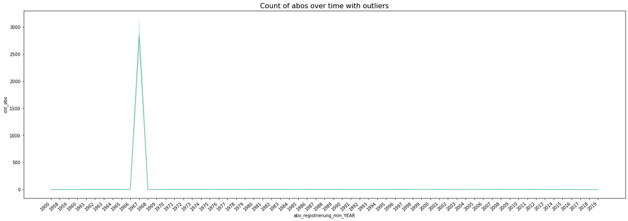

```python
labels = sorted(list(set([i for i in df["abo_registrierung_min_YEAR"]])))

plt.figure(figsize=(25,8))
plt.title("Count of abos over time with outliers", size=16)
g = sns.lineplot(data=df, x="abo_registrierung_min_YEAR", y="cnt_abo")
g.set_xticklabels(labels, rotation=40, ha="right");
```

```python
df = df[df.cnt_abo < 21]
```

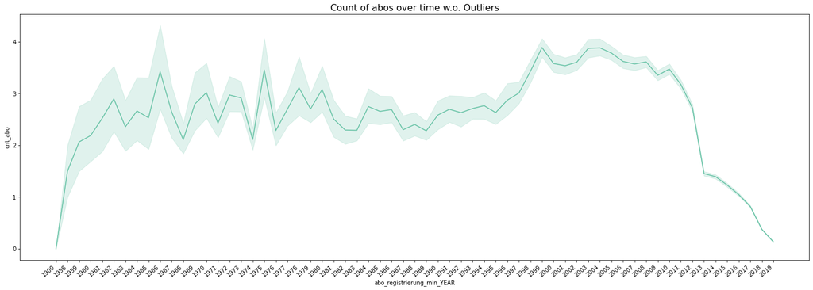

```python
labels = sorted(list(set([i for i in df["abo_registrierung_min_YEAR"]])))

plt.figure(figsize=(25,8))
plt.title("Count of abos over time w.o. Outliers", size=16)
g = sns.lineplot(data=df, x="abo_registrierung_min_YEAR", y="cnt_abo")
g.set_xticklabels(labels, rotation=40, ha="right");
```

**nl_blacklist_sum, nl_bounced_sum, nl_sperrliste_sum, nl_opt_in_sum**

- they have a majority of zero-values & the outliers are continouus
- we are only interested in the fact if a subscriber is featured or not
- we'll transform all NL_features into **dummies**

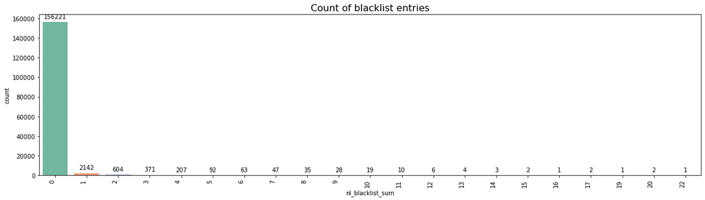

```python
plt.figure(figsize=(20,5))
f = sns.countplot(x=df.nl_blacklist_sum, data=df, palette="Set2");
f.set_xticklabels(f.get_xticklabels(), rotation=90, ha="right");
plt.title("Count of blacklist entries", size=16)
eda.add_count(f)
```

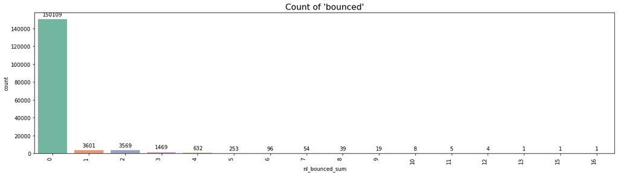

```python
plt.figure(figsize=(20,5))
f = sns.countplot(x=df.nl_bounced_sum, data=df, palette="Set2");
f.set_xticklabels(f.get_xticklabels(), rotation=90, ha="right");
plt.title("Count of 'bounced'", size=16)
eda.add_count(f)
```

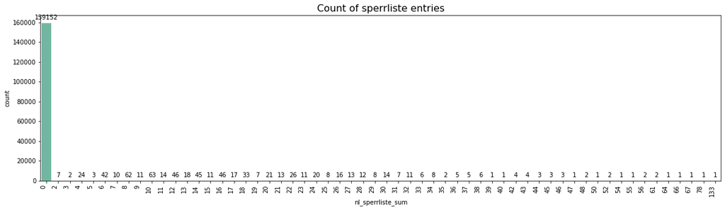

```python
plt.figure(figsize=(20,5))
f = sns.countplot(x=df.nl_sperrliste_sum, data=df, palette="Set2");
f.set_xticklabels(f.get_xticklabels(), rotation=90, ha="right");
plt.title("Count of sperrliste entries", size=16)
eda.add_count(f)
```

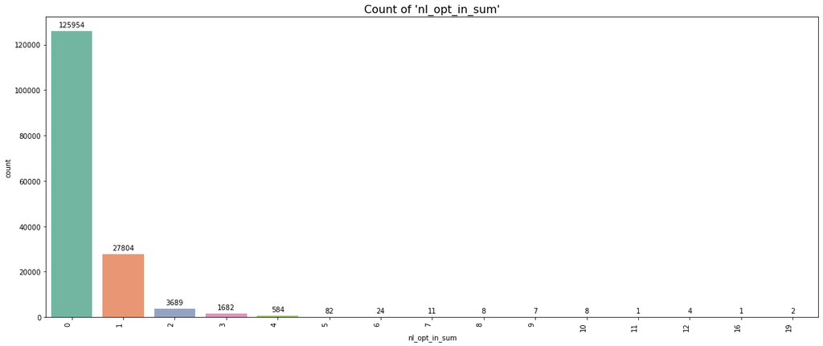

```python
plt.figure(figsize=(20,8))
f = sns.countplot(x=df.nl_opt_in_sum, data=df, palette="Set2");
f.set_xticklabels(f.get_xticklabels(), rotation=90, ha="right");
plt.title("Count of 'nl_opt_in_sum'", size=16)
eda.add_count(f)
```

```python
for i in df.iloc[: , lambda df: [45,46,49,50]]:
    df[i] = df[i].apply(eda.todumm)
```

```python
df.rename({"nl_blacklist_sum": "nl_blacklist_dum",
           "nl_bounced_sum": "nl_bounced_dum",
           "nl_sperrliste_sum": "nl_sperrliste_dum",
           "nl_opt_in_sum": "nl_opt_in_dum"}, axis=1, inplace=True)
```

### Newsletter columns:

**Received_anzahl**

- The columns `clickrate_3m` and `openrate_3m` contain values > 1.0. The are considered as outliers or discrepancies, as the value for a rate **cannot be greater 1.**
- A Further interpretation of the outliers based on the columns `received_anzahl_6m`, `opened_anzahl_6m`, `clicked_anzahl_6m` and `unsubscribed_anzahl_6m`is difficult because it is not clear which newsletters have been aggregated in the columns.
- As data seems to be continous, we just **delete the clickrates >1**

```python
df = df.query('openrate_bestandskunden_3m <= 1.0 & clickrate_bestandskunden_3m <= 1.0 & \
               openrate_bestandskunden_1w <= 1.0 & clickrate_bestandskunden_1w <= 1.0 & \
               openrate_bestandskunden_1m <= 1.0 & clickrate_bestandskunden_1m <= 1.0')
```

**Received_anzahl_bestandskunden**

```python
df.received_anzahl_bestandskunden_1w.value_counts()
```

```
0    152164
1      7590
4         8
2         2
Name: received_anzahl_bestandskunden_1w, dtype: int64
```

```python
df = df[df.received_anzahl_bestandskunden_1w < 4]
```

```python
df = df.query('openrate_bestandskunden_3m <= 1.0 & clickrate_bestandskunden_3m <= 1.0 & \
               openrate_bestandskunden_1w <= 1.0 & clickrate_bestandskunden_1w <= 1.0 & \
               openrate_bestandskunden_1m <= 1.0 & clickrate_bestandskunden_1m <= 1.0')
```

**Produktnews Newsletter:**

- Regarding the counts of received or opened there do not seem to be many outliers
- Regarding the click-, & openrates we again need to delete all rows with **values >1**

```python
df.received_anzahl_produktnews_6m.value_counts()
```

```
0     126093
1      19858
2       8807
3       2772
4        651
7        568
6        336
8        313
5        272
9         70
32         8
12         4
16         1
13         1
11         1
10         1
Name: received_anzahl_produktnews_6m, dtype: int64
```

```python
df = df[df.received_anzahl_produktnews_6m < 14]
```

```python
df = df.query('openrate_produktnews_3m <= 1.0 & clickrate_produktnews_3m <= 1.0 & \
               openrate_produktnews_1w <= 1.0 & clickrate_produktnews_1w <= 1.0 & \
               openrate_produktnews_1m <= 1.0 & clickrate_produktnews_1m <= 1.0')
```

**Hamburg Newsletter:**

- There is continouus data up to 126 and some **outliers at 472 and 500.**
- Regarding the click-, & openrates we again need to delete all rows with values >1

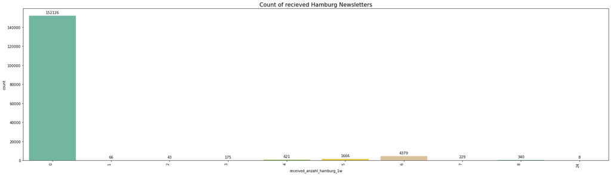

```python
plt.figure(figsize=(30,8))
f = sns.countplot(x=df.received_anzahl_hamburg_1w, data=df, palette="Set2");
f.set_xticklabels(f.get_xticklabels(), rotation=90, ha="right");
plt.title("Count of recieved Hamburg Newsletters", size=16)
eda.add_count(f)
```

```python
df = df[df.received_anzahl_hamburg_6m < 130]
```

```python
df = df.query('openrate_hamburg_3m <= 1.0 & clickrate_hamburg_3m <= 1.0 & \
               openrate_hamburg_1w <= 1.0 & clickrate_hamburg_1w <= 1.0 & \
               openrate_hamburg_1m <= 1.0 & clickrate_hamburg_1m <= 1.0')
```

**Zeitbrief:**

- **over 99%** of the subscribers received (and opened) **less than 29 newsletters** in the last 6m
- the outliers have common features like the same dates for "liefer_beginn"

```python
df_zb_abo = df.query('received_anzahl_zeitbrief_6m >1')
```

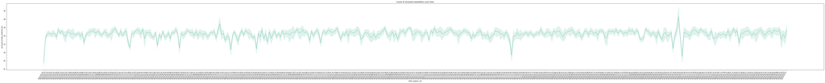

```python
labels = sorted(list(set([i for i in df_zb_abo["liefer_beginn_evt"]])))

plt.figure(figsize=(95,8))
plt.title("Count of received newsletters over time")
t = sns.lineplot(data=df_zb_abo, x="liefer_beginn_evt", y="received_anzahl_zeitbrief_6m")
t.set_xticklabels(labels, rotation=60, ha="right");
```

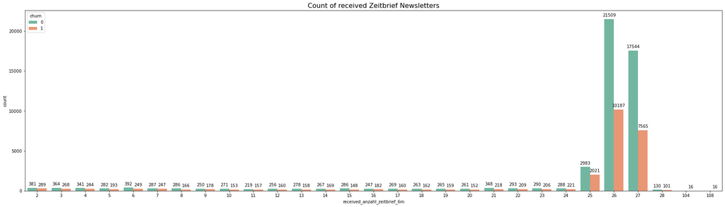

```python
plt.figure(figsize=(30,8))
plt.title("Count of received Zeitbrief Newsletters", size=16);
f = sns.countplot(data=df_zb_abo, x="received_anzahl_zeitbrief_6m", hue='churn');
eda.add_count(f)
```

We are setting max values for all opened/received columns regarding common sense & descriptives:

```python
df = df[df.received_anzahl_zeitbrief_1w < 3]
df = df[df.received_anzahl_zeitbrief_1m < 7]
df = df[df.received_anzahl_zeitbrief_3m < 16]
df = df[df.received_anzahl_zeitbrief_6m < 29]
df = df[df.opened_anzahl_zeitbrief_1w < 3]
df = df[df.opened_anzahl_zeitbrief_1m < 7]
df = df[df.opened_anzahl_zeitbrief_3m < 16]
df = df[df.opened_anzahl_zeitbrief_6m < 29]
```

- you can't open more emails than you received, therefore we delete all **rates with values >1** (1593 rows):

```python
df = df.query('openrate_zeitbrief_3m <= 1.0 & clickrate_zeitbrief_3m <= 1.0 & \
               openrate_zeitbrief_1w <= 1.0 & clickrate_zeitbrief_1w <= 1.0 & \
               openrate_zeitbrief_1m <= 1.0 & clickrate_zeitbrief_1m <= 1.0')
```

### Data Cleaning Summary:

```python
print('Our original data set has {0} observations.'.format(df_origin.shape[0]))
print('{0} Duplicates have been removed.'.format(df_origin.shape[0] - df_dup.shape[0]))
print('This is {}% of the original data set.'.format(round(((df_origin.shape[0]-df_dup.shape[0])/df_origin.shape[0])*100, 2)))
print('{0} Outliers have been removed.'.format(df_na.shape[0] - df.shape[0]))
print('This is {}% of the original data set.'.format(round(((df_na.shape[0]-df.shape[0])/df_origin.shape[0])*100, 2)))
print('The cleaned data set has {0} observations.'.format(df.shape[0]))
```

```
Our original data set has 209043 observations.
48319 Duplicates have been removed.
This is 23.11% of the original data set.
4211 Outliers have been removed.
This is 2.01% of the original data set.
The cleaned data set has 156428 observations.
```

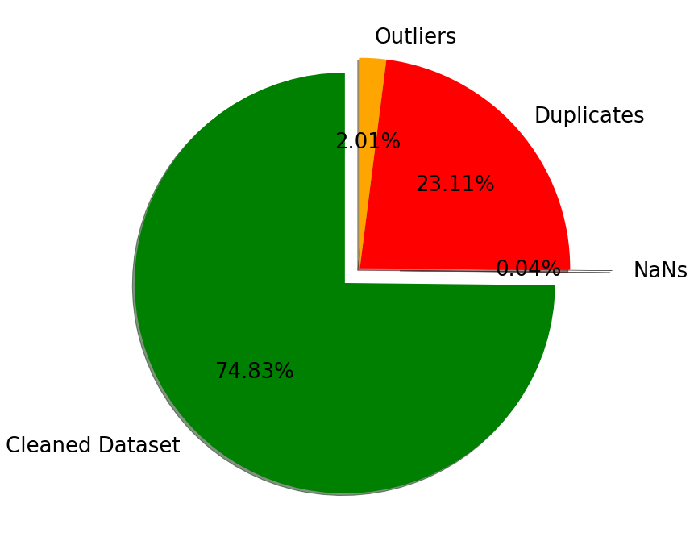

```python
fig, ax = plt.subplots(figsize=(12, 12), frameon=False)

font = FontProperties()
font.set_family('serif')
font.set_name('Times New Roman')
font.set_style('italic')

pieLabels = 'Cleaned Dataset', 'NaNs', 'Duplicates', 'Outliers'
popShare = [(df.shape[0]), (df_dup.shape[0]-df_na.shape[0]), df_temp_duplicates.shape[0], df_na.shape[0]-df.shape[0]]
colors  = ["green", "black", "red", "orange"]
explode = (0.1, 0.2, 0, 0)

pies = ax.pie(popShare,
        labels=pieLabels,
        explode=explode,
        colors = colors,
        autopct='%1.2f%%',
        textprops={'fontsize': 26},
        startangle=90)

for w in pies[0]:
    w.set_gid(w.get_label())
    w.set_edgecolor("none")

for w in pies[0]:
    s = Shadow(w, -0.01, -0.01)
    s.set_gid(w.get_gid() + "_shadow")
    s.set_zorder(w.get_zorder() - 0.1)
    ax.add_patch(s)

plt.savefig('00_plots/pie.png')
plt.show()
```

## **4 - Exploring the data in more depth**

### **4.1 - Target Variable: `churn`**

Since **churn** is our target variable, we will shortly inspect in more detail

```python
df.churn.value_counts(1)
```

```
0   0.691
1   0.309
Name: churn, dtype: float64
```

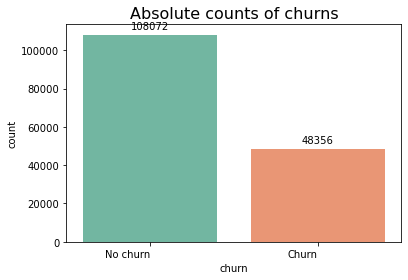

```python
f1 = sns.countplot(x=df.churn, data=df);
f1.set_title("Absolute counts of churns", fontsize=16);
f1.set_xticklabels(labels=["No churn", "Churn"], ha="right");
eda.add_count(f1)
```

It can be concluded, that our **target variable is imbalanced**.

- 69.1% of the sample remain in their subscription.
- 30.9% of the sample churn from their subscription.

This has to be taken into account for the modelling part.

### **4.2 - Demografics**

Plot correlations against `churn` for the demographics:

```python
df.iloc[:, :21].columns
```

```
Index(['liefer_beginn_evt', 'kanal', 'objekt_name', 'aboform_name',
       'zahlung_rhythmus_name', 'lesedauer', 'rechnungsmonat',
       'zahlung_weg_name', 'studentenabo', 'plz_1', 'plz_2', 'plz_3', 'ort',
       'metropole', 'land_iso_code', 'shop_kauf', 'unterbrechung', 'anrede',
       'titel', 'avg_churn', 'email_am_kunden'],
      dtype='object')
```

```python
df_corr = df[['churn','liefer_beginn_evt', 'kanal', 'objekt_name', 'aboform_name',
       'zahlung_rhythmus_name', 'lesedauer', 'rechnungsmonat',
       'zahlung_weg_name', 'studentenabo', 'plz_1', 'plz_2', 'plz_3', 'ort',
       'metropole', 'land_iso_code', 'shop_kauf', 'unterbrechung', 'anrede',
       'titel', 'avg_churn', 'email_am_kunden']]
```

[output not shown]

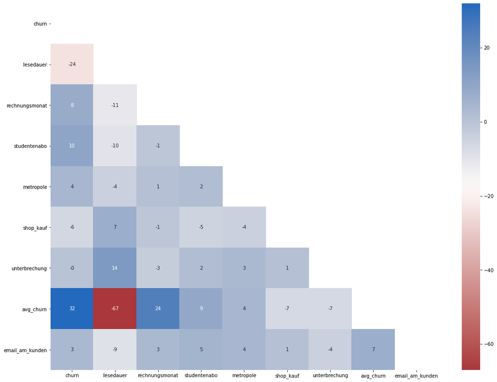

```python
eda.correlation(df_corr)
```

Most demographic features have only weak to no correlations with our target variable, which is not surprising as they are mostly binary - like structured.

**liefer_beginn_evt**

```python
print (df.liefer_beginn_evt.min())
print (df.liefer_beginn_evt.max())
```

```
2013-01-03
2019-05-23
```

**Kanal**

This variable describes, how a subscription was acquired.

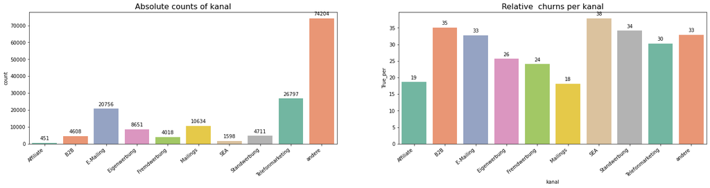

```python
fig, axes = plt.subplots(ncols=2, nrows=1, figsize=(25, 5))

crosstab_kanal_name = eda.make_crosstab(df, "kanal")

f1 = sns.countplot(x=sorted(df.kanal), data=df, ax=axes[0], palette="Set2");
f1.set_title("Absolute counts of kanal", fontsize=16);
f1.set_xticklabels(f1.get_xticklabels(),rotation=40, ha="right");
eda.add_count(f1)

f3 = sns.barplot(data=crosstab_kanal_name, x="kanal", y="True_per", ax=axes[1], palette="Set2")
f3.set_title("Relative  churns per kanal", fontsize=16);
f3.set_xticklabels(f3.get_xticklabels(),rotation=40, ha="right");
eda.add_count(f3)
```

On the left side it becomes evident, that the aquisition channel called **"andere"** is mostly used. Regarding the churn rate, the highest churn rate can be seen for **"SEA"** and the lowest for **"Mailings"**.

**objekt_name**

```python
df.objekt_name.value_counts(1)
```

```
DIE ZEIT                   0.565
ZEIT Digital               0.400
DIE ZEIT - CHRIST & WELT   0.035
Name: objekt_name, dtype: float64
```

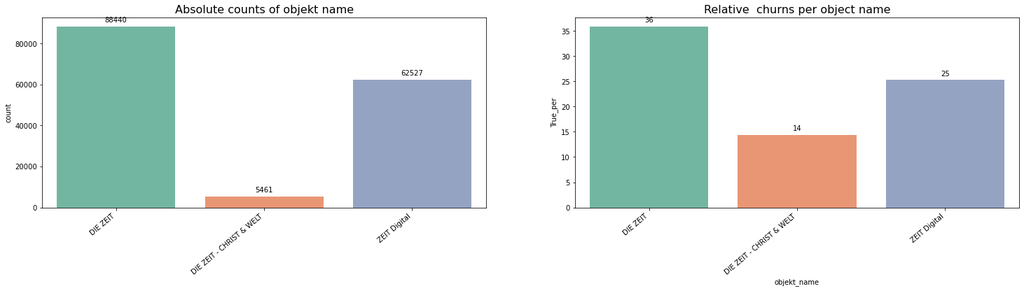

```python
fig, axes = plt.subplots(ncols=2, nrows=1, figsize=(25, 5))

crosstab_objekt_name = eda.make_crosstab(df, "objekt_name")

f1 = sns.countplot(x=sorted(df.objekt_name), data=df, ax=axes[0], palette="Set2");
f1.set_title("Absolute counts of objekt name", fontsize=16);
f1.set_xticklabels(f1.get_xticklabels(),rotation=40, ha="right");
eda.add_count(f1)


f3 = sns.barplot(data=crosstab_objekt_name, x="objekt_name", y="True_per", ax=axes[1],palette="Set2")
f3.set_title("Relative  churns per object name", fontsize=16);
f3.set_xticklabels(f3.get_xticklabels(),rotation=40, ha="right");
eda.add_count(f3)
```

### Future Market: Zeit Digital development since introduction (2011):

```python
df["lieferbeginn_YEAR"] = df["liefer_beginn_evt"].apply(lambda x: x.split()[0].split("-")[0])
df = df.sort_values(by=['lieferbeginn_YEAR'])
```

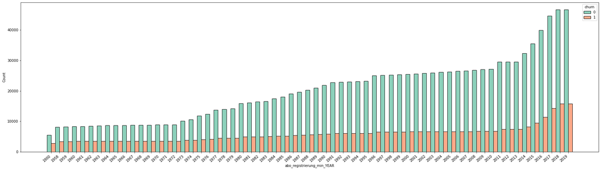

```python
df_digi = df.query("objekt_name == 'ZEIT Digital'")

labels = sorted(list(set([i for i in df["abo_registrierung_min_YEAR"]])))
plt.figure(figsize=(30,8), frameon=False)
digi = sns.histplot(data=df_digi, x="abo_registrierung_min_YEAR", hue='churn', multiple = 'dodge', cumulative = True, palette="Set2")
digi.set_xticklabels(labels, rotation=40, ha="right")

plt.savefig('00_plots/digi_since.png', transparent = True)
```

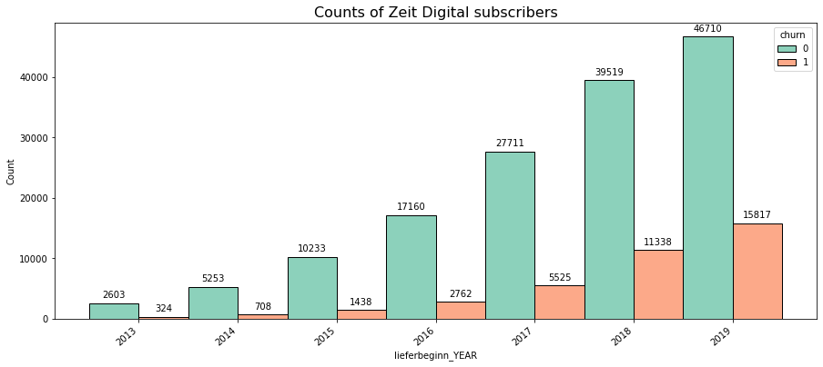

```python
df_digi = df.query("objekt_name == 'ZEIT Digital'")

labels = sorted(list(set([i for i in df["lieferbeginn_YEAR"]])))
plt.figure(figsize=(15,6), frameon=False)

digi = sns.histplot(data=df_digi, x="lieferbeginn_YEAR", hue='churn', multiple = 'dodge', cumulative = True, palette="Set2")
digi.set_xticklabels(labels, rotation=40, ha="right");
digi.set_title("Counts of Zeit Digital subscribers", fontsize=16)
eda.add_count(digi)

plt.savefig('00_plots/digi_development.png', transparent = True)
```

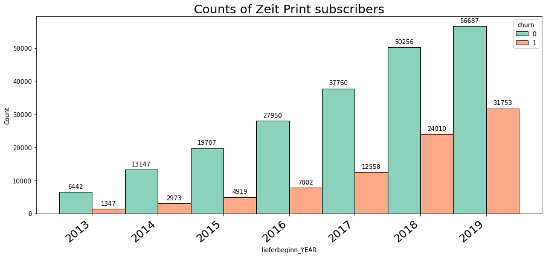

```python
df_digi = df.query("objekt_name == 'DIE ZEIT'")

labels = sorted(list(set([i for i in df["lieferbeginn_YEAR"]])))
plt.figure(figsize=(15,6), frameon=False)
druck = sns.histplot(data=df_digi, x="lieferbeginn_YEAR", hue='churn', multiple = 'dodge', cumulative = True, palette="Set2")
druck.set_xticklabels(labels, rotation=40, ha="right", fontsize=18);
druck.set_title("Counts of Zeit Print subscribers", fontsize=20)
eda.add_count(druck)

plt.savefig('00_plots/print_development.png', transparent = True)
```

**aboform_name**

The **Festabo** is most commonly used. The highest churn rates can be observed for **Geschenkabos** and **Negative Option**.

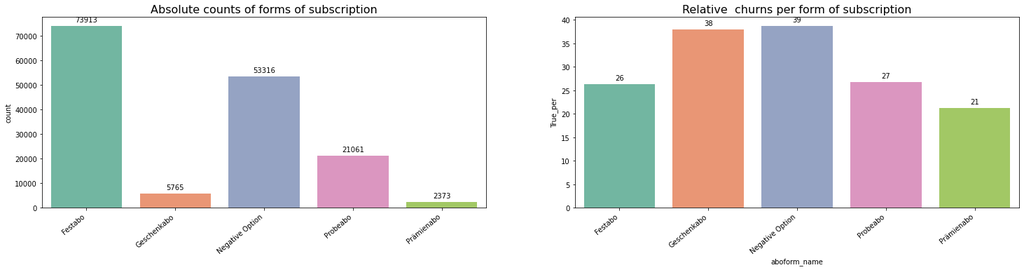

```python
fig, axes = plt.subplots(ncols=2, nrows=1, figsize=(25, 5))

crosstab_aboform_name = eda.make_crosstab(df, "aboform_name")

f1 = sns.countplot(x=sorted(df.aboform_name), data=df, ax=axes[0], palette="Set2");
f1.set_title("Absolute counts of forms of subscription", fontsize=16);
f1.set_xticklabels(f1.get_xticklabels(),rotation=40, ha="right");
eda.add_count(f1)


f3 = sns.barplot(data=crosstab_aboform_name, x="aboform_name", y="True_per", ax=axes[1],palette="Set2")
f3.set_title("Relative  churns per form of subscription", fontsize=16);
f3.set_xticklabels(f3.get_xticklabels(),rotation=40, ha="right");
eda.add_count(f3)
```

**lesedauer**

- For the time between subscription and cancellation, there is a clear trend to be observed.
- At the end of **every contract year** (12 months, 24 months and so on), an **increase of cancellations** can be seen (take a look at the graph above).

**But:**

- The lesedauer for non_churners is set on a randomly generated Date in 05/2019- 05/2020.
- This leads in some cases to non-churners who subscribed in 2018 having a shorter "lesedauer" than people who subscribed in 2018 and churned in 2019.
- Therefore we create a new feature `Vertragsdauer` in **5. Feature Enginnering** and repeat the analysis.

```python
df.lesedauer.describe()
```

```
count   156,428.000
mean         31.651
std          21.472
min           0.000
25%          13.000
50%          26.000
75%          46.000
max          88.000
Name: lesedauer, dtype: float64
```

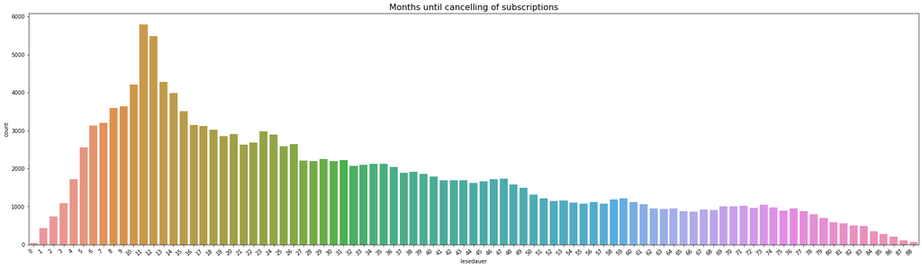

```python
plt.figure(figsize=(30,8))
f = sns.countplot(x=df.lesedauer, data=df);
f.set_title("Months until cancelling of subscriptions", fontsize=16);
f.set_xticklabels(f.get_xticklabels(), rotation=40, ha="right");
```

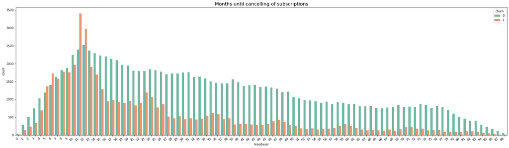

```python
plt.figure(figsize=(30,8))
custom_palette_2 = ["navy", "indianred"]
f = sns.countplot(x=df.lesedauer, data=df, hue="churn", palette="Set2");
f.set_title("Months until cancelling of subscriptions", fontsize=16);
f.set_xticklabels(f.get_xticklabels(), rotation=40, ha="right");
```

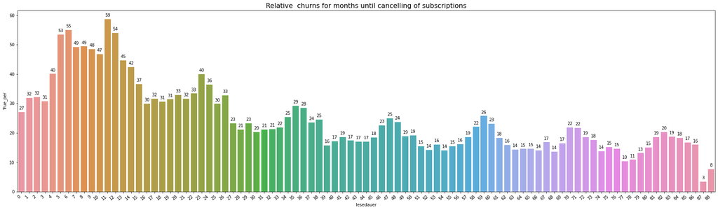

```python
crosstab_lesedauer = eda.make_crosstab(df, "lesedauer")

plt.figure(figsize=(30,8))
f3 = sns.barplot(data=crosstab_lesedauer, x="lesedauer", y="True_per")
f3.set_title("Relative  churns for months until cancelling of subscriptions", fontsize=16);
f3.set_xticklabels(f3.get_xticklabels(),rotation=40, ha="right");
eda.add_count(f3)
```

**zahlung_rhythmus_name**

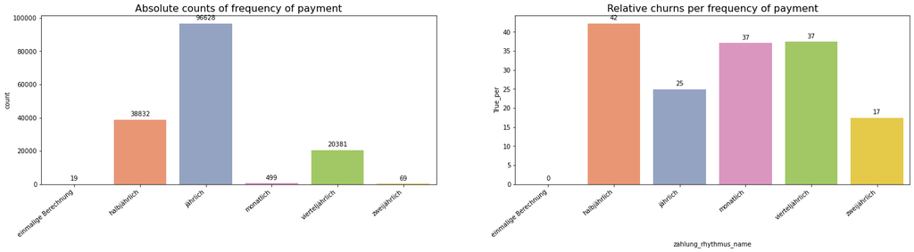

```python
fig, axes = plt.subplots(ncols=2, nrows=1, figsize=(25, 5))

crosstab_zahlung_rhythmus = eda.make_crosstab(df, "zahlung_rhythmus_name")

f1 = sns.countplot(x=sorted(df.zahlung_rhythmus_name), data=df, ax=axes[0], palette="Set2");
f1.set_title("Absolute counts of frequency of payment", fontsize=16);
f1.set_xticklabels(f1.get_xticklabels(),rotation=40, ha="right");
eda.add_count(f1)


f3 = sns.barplot(data=crosstab_zahlung_rhythmus, x="zahlung_rhythmus_name", y="True_per", ax=axes[1],palette="Set2")
f3.set_title("Relative churns per frequency of payment", fontsize=16);
f3.set_xticklabels(f3.get_xticklabels(),rotation=40, ha="right");
eda.add_count(f3)
```

**zahlung_weg_name**

- Traditional payment methods are the most common (Bankeinzug and Rechnung).
- Regarding the used payment method, significant differences in the churn rate can be seen:
- For **Rechnung** we have the highest churn rate, whereas the **Bankeinzug** shows the lowest churn rate.

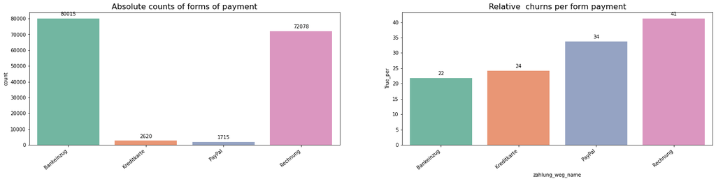

```python
fig, axes = plt.subplots(ncols=2, nrows=1, figsize=(25, 5))

crosstab_zahlung_weg_name = eda.make_crosstab(df, "zahlung_weg_name")

f1 = sns.countplot(x=sorted(df.zahlung_weg_name), data=df, ax=axes[0], palette="Set2");
f1.set_title("Absolute counts of forms of payment", fontsize=16);
f1.set_xticklabels(f1.get_xticklabels(),rotation=40, ha="right");
eda.add_count(f1)


f3 = sns.barplot(data=crosstab_zahlung_weg_name, x="zahlung_weg_name", y="True_per", ax=axes[1],palette="Set2")
f3.set_title("Relative  churns per form payment", fontsize=16);
f3.set_xticklabels(f3.get_xticklabels(),rotation=40, ha="right");
eda.add_count(f3)
```

**studentenabo**

- Only 10.5% of the subscribers are students.
- Looking at the graph on the right side, it becomes clear that **students are more likely to cancel** their subscription.

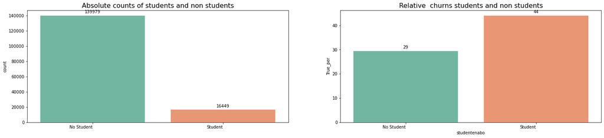

```python
fig, axes = plt.subplots(ncols=2, nrows=1, figsize=(25, 5))

crosstab_student = eda.make_crosstab(df, "studentenabo")


f1 = sns.countplot(x=sorted(df.studentenabo), data=df, ax=axes[0], palette="Set2");
f1.set_title("Absolute counts of students and non students", fontsize=16);
f1.set_xticklabels(labels=["No Student", "Student"], ha="right");
eda.add_count(f1)


f3 = sns.barplot(data=crosstab_student, x="studentenabo", y="True_per", ax=axes[1],palette="Set2")
f3.set_title("Relative  churns students and non students", fontsize=16);
f3.set_xticklabels(labels=["No Student", "Student"], ha="right");
eda.add_count(f3)
```

**plz_1**

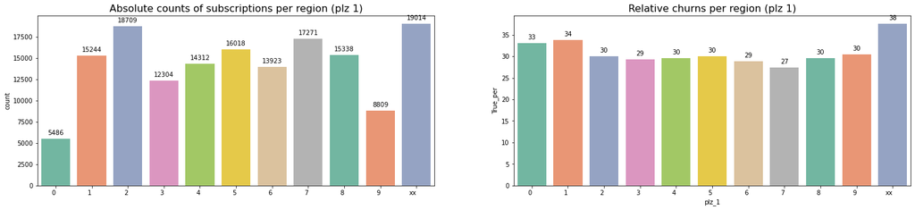

```python
fig, axes = plt.subplots(ncols=2, nrows=1, figsize=(25, 5))

crosstab_plz_1 = eda.make_crosstab(df, "plz_1")


f1 = sns.countplot(x=sorted(df.plz_1), data=df, ax=axes[0],palette="Set2");
f1.set_title("Absolute counts of subscriptions per region (plz 1)", fontsize=16);
f1.set_xticklabels(f1.get_xticklabels(), ha="right");
eda.add_count(f1)


f3 = sns.barplot(data=crosstab_plz_1, x="plz_1", y="True_per", ax=axes[1],palette="Set2")
f3.set_title("Relative churns per region (plz 1)", fontsize=16);
f3.set_xticklabels(f3.get_xticklabels(), ha="right");
eda.add_count(f3)
```

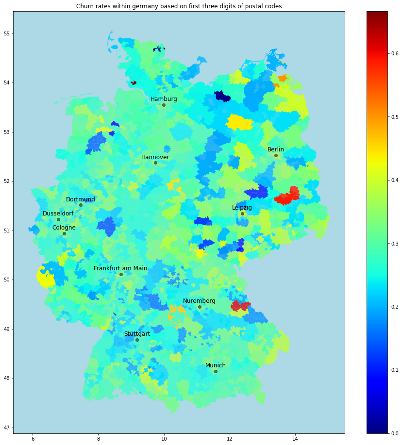

```python
eda.create_plz_plot()
```

Looking at the map above, it is hard to observe a clear trend regarding geografics and churn rates. In the eastern part of germany there seem to be more yellow areas, which indicate a higher churn rate.

**land_iso_code**

- 87.8% of the subscribers come from germany, followed by Austria(6.3%) and Switzerland (3.5%)and others (2.4%).
- The **highest churn rate achieve the subscribers from Austria and other countries**
- **german subscribers** are most likely to maintain their subscription in comparison to the other countries

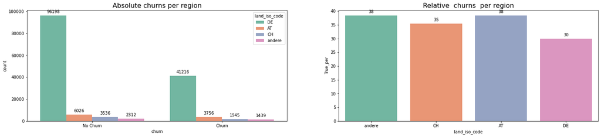

```python
fig, axes = plt.subplots(ncols=2, nrows=1, figsize=(25, 5))

crosstab_land = eda.make_crosstab(df, "land_iso_code")
crosstab_land = crosstab_land.reindex([3,1,0,2])

f1 = sns.countplot(x=df.churn, hue=df["land_iso_code"], data=df, palette="Set2", ax=axes[0]);
f1.set_title("Absolute churns per region", fontsize=16);
f1.set_xticklabels(["No Churn", "Churn"]);
eda.add_count(f1)

f3 = sns.barplot(data=crosstab_land, x="land_iso_code", y="True_per", palette="Set2", ax=axes[1])
f3.set_title("Relative  churns  per region", fontsize=16);
eda.add_count(f3)
```

**titel**

```python
df.titel.value_counts()
```

```
kein Titel            141129
akademischer Titel     13253
sonstiger Titel         2046
Name: titel, dtype: int64
```

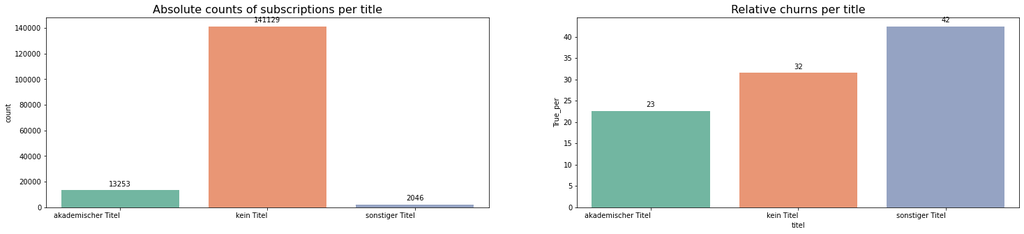

```python
fig, axes = plt.subplots(ncols=2, nrows=1, figsize=(25, 5))

crosstab_titel = eda.make_crosstab(df, "titel")


f1 = sns.countplot(x=sorted(df.titel), data=df, ax=axes[0], palette="Set2");
f1.set_title("Absolute counts of subscriptions per title", fontsize=16);
f1.set_xticklabels(f1.get_xticklabels(), ha="right");
eda.add_count(f1)


f3 = sns.barplot(data=crosstab_titel, x="titel", y="True_per", ax=axes[1], palette="Set2")
f3.set_title("Relative churns per title", fontsize=16);
f3.set_xticklabels(f3.get_xticklabels(), ha="right");
eda.add_count(f3)
```